# Draft

### Draft Analyzer

Creating a draft prediction system that can take in a players combine stats and output the position they play.

```python
import requests
import pandas as pd
import numpy as np

def getdraftlinks(year):
    url = 'https://nflcombineresults.com/nflcombinedata.php?year='+str(year)+'&pos=&college='
    html = requests.get(url).content
    df_list = pd.read_html(html)
    return df_list[-1]

d2020 = getdraftlinks(2020)
d2019 = getdraftlinks(2019)
d2018 = getdraftlinks(2018)
d2017 = getdraftlinks(2017)
d2016 = getdraftlinks(2016)
d2015 = getdraftlinks(2015)
d2014 = getdraftlinks(2014)
d2013 = getdraftlinks(2013)
d2012 = getdraftlinks(2012)
d2011 = getdraftlinks(2011)
d2010 = getdraftlinks(2010)
```

```python
pd.set_option('mode.chained_assignment', None)
```

```python
frames = [d2020, d2019,d2018,d2017,d2016,d2015,d2014,d2013,d2012,d2011,d2010]

draft = pd.concat(frames)
draft.set_index('Name')
draft.drop(['Year', 'College', 'Unnamed: 13', 'Unnamed: 14','Wonderlic'], axis =1, inplace = True)
draft = draft.set_index('Name')
draft
```

| Name | POS | Height (in) | Weight (lbs) | 40 Yard | Bench Press | Vert Leap (in) | Broad Jump (in) | Shuttle | 3Cone |
| --- | --- | --- | --- | --- | --- | --- | --- | --- | --- |
| Trey Adams | OT | 80.00 | 314.0 | 5.60 | NaN | 24.5 | 92.0 | 9.99 | 9.99 |
| Hakeem Adeniji | OG | 76.00 | 302.0 | 5.17 | 26.0 | 34.0 | 115.0 | 9.99 | 9.99 |
| McTelvin Agim | DT | 75.00 | 300.0 | 4.98 | 27.0 | NaN | NaN | 9.99 | 9.99 |
| Salvon Ahmed | RB | 71.00 | 196.0 | 4.62 | NaN | 34.5 | 120.0 | 9.99 | 9.99 |
| Brandon Aiyuk | WR | 72.00 | 201.0 | 4.50 | 11.0 | 40.0 | 128.0 | 9.99 | 9.99 |
| ... | ... | ... | ... | ... | ... | ... | ... | ... | ... |
| Doug Worthington | DT | 77.13 | 292.0 | 5.02 | 19.0 | NaN | NaN | 9.99 | 9.99 |
| Major Wright | FS | 71.50 | 206.0 | 4.44 | 14.0 | 37.5 | 119.0 | 4.36 | 6.95 |
| Sam Young | OT | 79.63 | 316.0 | 5.20 | 29.0 | 29.5 | 104.0 | 4.87 | 7.73 |
| Willie Young | DE | 76.75 | 251.0 | 4.88 | 25.0 | 38.0 | 118.0 | 4.56 | 7.24 |
| NaN | NaN | NaN | NaN | NaN | NaN | NaN | NaN | NaN | NaN |

5354 rows × 9 columns

```python
draft.POS.unique()
```

```
array(['OT', 'OG', 'DT', 'RB', 'WR', 'DE', 'CB', 'S', 'TE', 'LB', 'K',
       'C', 'QB', 'P', 'LS', 'FB', 'ILB', nan, 'FS', 'OLB', 'EDG', 'OL',
       'SS', 'DB', 'DL', 'NT'], dtype=object)
```

Some changes here have to be made, Nose Tackles are the same as Defensive Tackles and FS, CB, SS are all "DBs". Same with there being OT, OG along with "Offensive Lineman" for the sake of this project will group some together.

```python
draft['POS'] = draft['POS'].replace(['OT','OG','C'],'OL')
draft['POS'] = draft['POS'].replace(['CB','FS','SS','S'],'DB')
draft['POS'] = draft['POS'].replace(['EDG'],'OLB')
draft['POS'] = draft['POS'].replace(['LB'],'ILB')
draft['POS'] = draft['POS'].replace(['DE','DT','NT'],'DL')
```

```python
draft.isna().sum()
```

```
POS                  11
Height (in)          11
Weight (lbs)         11
40 Yard              11
Bench Press        2682
Vert Leap (in)     2448
Broad Jump (in)    2488
Shuttle              11
3Cone                11
dtype: int64
```

```python
draft.replace(9.99, np.nan, inplace = True)
```

```python
draft.columns
```

```
Index(['POS', 'Height (in)', 'Weight (lbs)', '40 Yard', 'Bench Press',
       'Vert Leap (in)', 'Broad Jump (in)', 'Shuttle', '3Cone'],
      dtype='object')
```

```python
draft = draft[draft['POS'].notna()]
draft.head()
#Cant have players without a listed position
```

| Name | POS | Height (in) | Weight (lbs) | 40 Yard | Bench Press | Vert Leap (in) | Broad Jump (in) | Shuttle | 3Cone |
| --- | --- | --- | --- | --- | --- | --- | --- | --- | --- |
| Trey Adams | OL | 80.0 | 314.0 | 5.60 | NaN | 24.5 | 92.0 | NaN | NaN |
| Hakeem Adeniji | OL | 76.0 | 302.0 | 5.17 | 26.0 | 34.0 | 115.0 | NaN | NaN |
| McTelvin Agim | DL | 75.0 | 300.0 | 4.98 | 27.0 | NaN | NaN | NaN | NaN |
| Salvon Ahmed | RB | 71.0 | 196.0 | 4.62 | NaN | 34.5 | 120.0 | NaN | NaN |
| Brandon Aiyuk | WR | 72.0 | 201.0 | 4.50 | 11.0 | 40.0 | 128.0 | NaN | NaN |

```python
draft['Shuttle'] = draft.groupby(['POS'])['Shuttle']\
    .transform(lambda x: x.fillna(x.mean()))
draft['3Cone'] = draft.groupby(['POS'])['3Cone']\
    .transform(lambda x: x.fillna(x.mean()))
draft['Height (in)'] = draft.groupby(['POS'])['Height (in)']\
    .transform(lambda x: x.fillna(x.mean()))
draft['Weight (lbs)'] = draft.groupby(['POS'])['Weight (lbs)']\
    .transform(lambda x: x.fillna(x.mean()))
draft['40 Yard'] = draft.groupby(['POS'])['40 Yard']\
    .transform(lambda x: x.fillna(x.mean()))
draft['Bench Press'] = draft.groupby(['POS'])['Bench Press']\
    .transform(lambda x: x.fillna(x.mean()))
draft['Vert Leap (in)'] = draft.groupby(['POS'])['Vert Leap (in)']\
    .transform(lambda x: x.fillna(x.mean()))
draft['Broad Jump (in)'] = draft.groupby(['POS'])['Broad Jump (in)']\
    .transform(lambda x: x.fillna(x.mean()))

draft.head()
```

| Name | POS | Height (in) | Weight (lbs) | 40 Yard | Bench Press | Vert Leap (in) | Broad Jump (in) | Shuttle | 3Cone |
| --- | --- | --- | --- | --- | --- | --- | --- | --- | --- |
| Trey Adams | OL | 80.0 | 314.0 | 5.60 | 25.182013 | 24.500000 | 92.000000 | 4.763671 | 7.818894 |
| Hakeem Adeniji | OL | 76.0 | 302.0 | 5.17 | 26.000000 | 34.000000 | 115.000000 | 4.763671 | 7.818894 |
| McTelvin Agim | DL | 75.0 | 300.0 | 4.98 | 27.000000 | 30.897982 | 110.778802 | 4.550380 | 7.469306 |
| Salvon Ahmed | RB | 71.0 | 196.0 | 4.62 | 19.310219 | 34.500000 | 120.000000 | 4.280048 | 7.046935 |
| Brandon Aiyuk | WR | 72.0 | 201.0 | 4.50 | 11.000000 | 40.000000 | 128.000000 | 4.249288 | 6.954808 |

```python
newdraft = draft.dropna().copy()
```

Now were ready for the classification! We begin by getting the X and Y variables into their own arrays/matricies.

```python
position = newdraft['POS']
draftmatrix = newdraft.drop(['POS'],axis = 1)
```

Matrix of the predictor variables. Split into training and testing data for future validation.

```python
from sklearn.model_selection import train_test_split
draft_train, draft_test, draft_target_train, draft_target_test = train_test_split(draftmatrix, position, test_size=0.2, random_state=33)

print(draft_test.shape)
draft_test[0:5]
```

```
(1055, 8)
```

| Name | Height (in) | Weight (lbs) | 40 Yard | Bench Press | Vert Leap (in) | Broad Jump (in) | Shuttle | 3Cone |
| --- | --- | --- | --- | --- | --- | --- | --- | --- |
| Javon Hargrave | 73.38 | 309.0 | 4.930000 | 29.000000 | 34.500000 | 109.000000 | 4.700000 | 7.900000 |
| Ryan Tannehill | 75.88 | 221.0 | 4.650000 | 17.875000 | 31.344512 | 112.066667 | 4.324545 | 7.087785 |
| Chris James | 69.63 | 215.0 | 4.554080 | 19.310219 | 34.620629 | 119.058182 | 4.280048 | 7.046935 |
| Chris Miller | 72.00 | 191.0 | 4.610000 | 12.000000 | 35.500000 | 133.000000 | 4.120000 | 7.090000 |
| Blake Hance | 77.63 | 305.0 | 5.249913 | 25.182013 | 27.637555 | 102.638202 | 4.763671 | 7.818894 |

List of the target variables

```python
draft_target_train
```

```
Name
Eric Ebron          TE
Cody Whitehair      OL
Riley Cooper        WR
Coty Sensabaugh     DB
Daniel Marx         FB
                  ...
Tyrie Cleveland     WR
Quinton Spain       OL
Brandon Bridge      QB
Terrill Hanks      ILB
Ryan Malleck        TE
Name: POS, Length: 4218, dtype: object
```

```python
from sklearn import neighbors
#first trying unnormalized data
n_neighbors = 5

knnclf = neighbors.KNeighborsClassifier(n_neighbors, weights='distance')
knnclf.fit(draft_train, draft_target_train)
```

```
KNeighborsClassifier(weights='distance')
```

Model is fit and ready to classify. Lets enter my own Pro Day result and see if the model knows what position I played.

```python
predicted= knnclf.predict([[74,245,4.7,20,34,120,4.2,7.01]])
predicted
```

```
array(['OLB'], dtype=object)
```

Technically I played Inside Linebacker but thats close enough!

```python
knnpreds_test = knnclf.predict(draft_test)
```

```python
from sklearn.metrics import classification_report
print(classification_report(draft_target_test, knnpreds_test))
```

```
              precision    recall  f1-score   support

          DB       0.66      0.72      0.69       186
          DL       0.79      0.74      0.77       171
          FB       0.71      0.63      0.67        19
         ILB       0.52      0.55      0.53        55
          LS       1.00      0.40      0.57         5
          OL       0.84      0.89      0.87       178
         OLB       0.62      0.57      0.59        81
           P       0.55      0.58      0.56        19
          QB       0.84      0.73      0.78        56
          RB       0.70      0.66      0.68        89
          TE       0.64      0.72      0.68        57
          WR       0.63      0.62      0.63       139

    accuracy                           0.71      1055
   macro avg       0.71      0.65      0.67      1055
weighted avg       0.71      0.71      0.71      1055
```

```python
#same thing except with scaled data
from sklearn import preprocessing
min_max_scaler = preprocessing.MinMaxScaler().fit(draft_train)

draft_train_norm = min_max_scaler.transform(draft_train)
draft_train_norm = pd.DataFrame(draft_train_norm, columns=draft_train.columns, index=draft_train.index)

draft_test_norm = min_max_scaler.transform(draft_test)
draft_test_norm = pd.DataFrame(draft_test_norm, columns=draft_test.columns, index=draft_test.index)
```

```python
draft_train_norm.head()
```

| Name | Height (in) | Weight (lbs) | 40 Yard | Bench Press | Vert Leap (in) | Broad Jump (in) | Shuttle | 3Cone |
| --- | --- | --- | --- | --- | --- | --- | --- | --- |
| Eric Ebron | 0.734177 | 0.427966 | 0.237805 | 0.468085 | 0.537037 | 0.584615 | 0.367193 | 0.359420 |
| Cody Whitehair | 0.702278 | 0.644068 | 0.493902 | 0.297872 | 0.296296 | 0.430769 | 0.490446 | 0.426230 |
| Riley Cooper | 0.683544 | 0.309322 | 0.195122 | 0.261919 | 0.574074 | 0.492308 | 0.279801 | 0.276561 |
| Coty Sensabaugh | 0.474430 | 0.169492 | 0.073171 | 0.276596 | 0.722222 | 0.615385 | 0.159236 | 0.131148 |
| Daniel Marx | 0.563038 | 0.406780 | 0.352388 | 0.416609 | 0.571087 | 0.489330 | 0.352206 | 0.390290 |

```python
knnclf.fit(draft_train_norm, draft_target_train) #fitting the data
knnpreds_test_norm = knnclf.predict(draft_test_norm) #predicting new test instances
print(classification_report(draft_target_test, knnpreds_test_norm))
```

```
              precision    recall  f1-score   support

          DB       0.75      0.79      0.77       186
          DL       0.87      0.78      0.82       171
          FB       0.67      0.74      0.70        19
         ILB       0.65      0.67      0.66        55
          LS       0.80      0.80      0.80         5
          OL       0.87      0.92      0.90       178
         OLB       0.67      0.64      0.65        81
           P       0.75      0.79      0.77        19
          QB       0.90      0.77      0.83        56
          RB       0.79      0.79      0.79        89
          TE       0.60      0.68      0.64        57
          WR       0.70      0.68      0.69       139

    accuracy                           0.77      1055
   macro avg       0.75      0.75      0.75      1055
weighted avg       0.77      0.77      0.77      1055
```

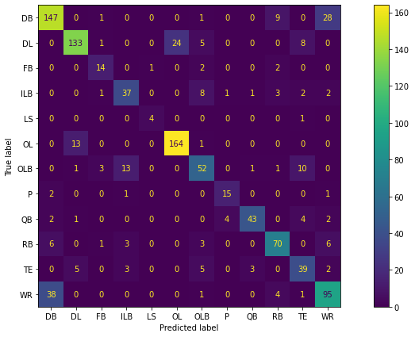

```python
import matplotlib.pyplot as plt
from sklearn.datasets import make_classification
from sklearn.metrics import plot_confusion_matrix
fig, ax = plt.subplots(figsize=(15, 7))
plot_confusion_matrix(knnclf, draft_test_norm, draft_target_test,ax=ax)  # doctest: +SKIP
plt.show()
```

The Confusion matrix shows a visual representation of predicted vs actual classifications. The models biggest perpertrators of wrong classifications are WRs-DB, OLB-ILB, OL-DL. These make sense from purely size and athletic standpoint WRs and DBs are fast and quick, scoring highly on vertical, 3cone, shuttle and 40. WRs might be slightly taller on average than DBs as a point of differentiation. OLB and ILB are very similar and are often times interchangable on the field. OL and DL are just the big boys up front, with much slower athletic abilities.